# MSDS 400 Practice Final Solutions

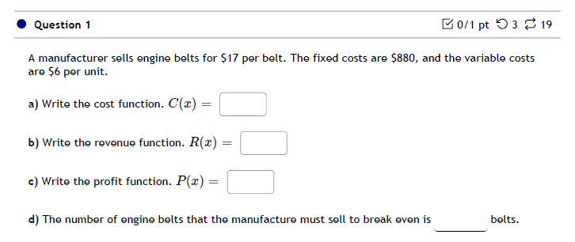

**Setup:** Let x be the number of belts
a) Cost function:: $$C(x) = 6x + 880$$
b) Revenue Function:: $$R(x) = 17x$$
c) Profit function:: $$P(x) = 11x - 880$$
d) To find break-even point set profit function to 0 and solve for x.

** See code below **

```python
# Using sympy library we setup a linear equation in one variable
# and solve for x
from sympy import Eq, Symbol, solve

x = Symbol('x')
# The following represents 11x-880=0
eqn = Eq(11*x-880, 0)

# The solve(eqn) returns a list of values. Use the first element in this case
# since there is only one variable
print("The number of engine belts to break even =",solve(eqn)[0])
```

```
The number of engine belts to break even = 80
```

**Problem 1**
To solve algebraically:
$$11x - 880 = 0$$ $$11x = 880$$ $$x = 80$$

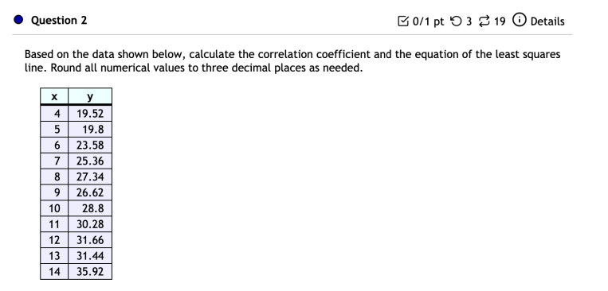

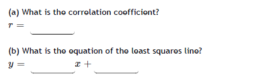

```python
%matplotlib inline

# Packages we can use
from scipy.stats.stats import pearsonr
import scipy.stats as st
import numpy as np
import matplotlib.pyplot as plt

'''
a. Draw a scatterplot.
Use numpy arrays to store x and y
'''
x = np.arange(4,15)
y = np.array([19.52,19.8,23.58,25.36,27.34,26.62,28.8,30.28,31.66,31.44,35.92])

'''
b. Calculate the correlation coefficient.

Two options- using the corrcoef function from numpy or pearsonr function
'''

print("\n(a)")

corr_np = np.corrcoef(x, y)[0, 1]
corr_sci = pearsonr(x, y)[0]
print("Option 1: Correlation Coefficient (corrcoef): ",round(corr_np,3))
print("Option 2: Correlation Coefficient (pearsonr): ",round(corr_sci,3))

'''
c. Calculate the least squares line and graph it on the scatterplot.
'''
'''
For deeper exploration of pyplot visit:
http://matplotlib.org/api/pyplot_api.html#matplotlib.pyplot
'''

# For details of the following step see part (d) below
slope,intercept,rvalue,pvalue,stderr = st.linregress(x,y)

print('\n(b)')
print('y = ',round(slope,3),'x ',round(intercept,3))
```

```
(a)
Option 1: Correlation Coefficient (corrcoef):  0.977
Option 2: Correlation Coefficient (pearsonr):  0.977

(b)
y =  1.492 x  13.875
```

**Problem 2**
Technology is recommended on Problem #2. If done by hand, use least squares calculations for the correlation coefficient and the equation of the least squares line.
$$r=\frac{n(\sum{}{}xy)-(\sum{}{}x)(\sum{}{}y)}{\sqrt{n(\sum{}{}x^2)-(\sum{}{}x)^2}\cdot\sqrt{n(\sum{}{}y^2)-(\sum{}{}y)^2}}$$
$$m=\frac{n(\sum{}{}xy)-(\sum{}{}x)(\sum{}{}y)}{n(\sum{}{}x^2)-(\sum{}{}x)^2}$$
$$b=\frac{\sum{}{}y-m(\sum{}{}x)}{n}$$
$n=11$
$\sum{}{}x=99$
$\sum{}{}y=300.32$
$\sum{}{}xy=2866.98$
$\sum{}{}x^2=1001$
$\sum{}{}y^2=8455.7104$

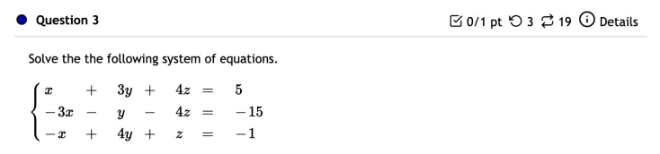

```python
import numpy as np

A = np.array([[1, 3, 4], [-3, -1, -4], [-1, 4, 1]])
B = np.array([5, -15, -1])
X = np.linalg.inv(A).dot(B)

print(X)
```

```
[ 7.  2. -2.]
```

**Problem 3**  
Technology is also recommended for Problem #3. To solve algebraically use row operations:  
\begin{equation} \begin{bmatrix} \begin{array}{ccc|c} 1 & 3 & 4 & 5 \\ -3 & -1 & -4 & -15 \\ -1 & 4 & 1 & -1 \\ \end{array} \end{bmatrix} \end{equation}  
$3R_1+R_2\rightarrow R_2$  
$R_1+R_3\rightarrow R_3$ \begin{equation} \begin{bmatrix} \begin{array}{ccc|c} 1 & 3 & 4 & 5 \\ 0 & 8 & 8 & 0 \\ 0 & 7 & 5 & 4 \\ \end{array} \end{bmatrix} \end{equation}  
$-7R_2+8R_3\rightarrow R_3$ \begin{equation} \begin{bmatrix} \begin{array}{ccc|c} 1 & 3 & 4 & 5 \\ 0 & 8 & 8 & 0 \\ 0 & 0 & -16 & 32 \\ \end{array} \end{bmatrix} \end{equation}  
$-16z=32\rightarrow z=-2$  
$8y+8(-2)=0\rightarrow y=2$  
$x+3(2)+4(-2)=5\rightarrow x=7$

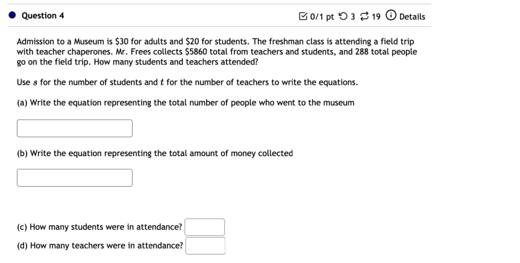

**Setup:**
(a) Total number of people $$ t + s = 288 $$

(b) Total amount of money collected
$$30t + 20s = 5860$$

```python
import numpy as np

A = np.array([[1, 1], [30, 20]])
B = np.array([288, 5860])
X = np.linalg.inv(A).dot(B)

print("(c) Number of students =",round(X[1],0))

print("(d) Number of teachers =",round(X[0],0))
```

```
(c) Number of students = 278.0
(d) Number of teachers = 10.0
```

**Problem 4**
Substitution can be use for Problem #4. First simplify the 2nd equation:
$$t+s=288$$ $$3t+2s=586$$
From the first equation, $t=288-s$. Substitute for $t$ in the 2nd equation and solve for $s$:
$3(288-s)+2s=586$
$864-3s+2s=586$
$-s=-278\rightarrow s=278$
$s=278\rightarrow t=10$

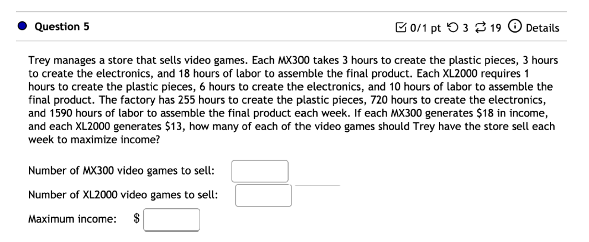

**Setup:** Let $x_1$ be the number of MX300 video games and let $x_2$ be the number of XL2000 video games  
Maximize: $z=18x_1 + 13x_2$  
Subject to: $3x_1 + x_2 \leq 255$  
$3x_1 + 6x_2 \leq 720$  
$18x_1 + 10x_2\leq 1590$  
$x_1 \geq 0, x_2 \geq 0$

If you have not installed **pulp**, uncomment the cell below and run the cell before running the code for the next two problems. Contact your TA if you run into difficulties.

```python
# !pip install pulp
```

```python
from pulp import LpVariable, LpProblem, LpMaximize, LpStatus, value, LpMinimize

# declare your variables
x1 = LpVariable("x1", 0, None) # x1>=0
x2 = LpVariable("x2", 0, None) # x2>=0

# defines the problem
prob = LpProblem("problem", LpMaximize)

# defines the constraints
prob += 3*x1 + x2 <= 255
prob += 3*x1 + 6*x2 <= 720
prob += 18*x1 + 10*x2 <= 1590

# defines the objective function to maximize
prob += 18*x1 + 13*x2

# solve the problem
status = prob.solve()
LpStatus[status]

# print the results
print(value(x1))
print(value(x2))
print(18*value(x1) + 13*value(x2))
```

```
30.0
105.0
1905.0
```

**Problem 5**  
If solving Problem #5 by hand, use the Simplex Method. First simplify the system:  
Maximize $18x_1+13x_2$  
s.t.  
$3x_1+x_2\leq 255$  
$x_1+2x_2\leq 240$  
$9x_1+5x_2\leq 795$  
$x_1\geq 0, x_2\geq 0$  
Set up the initial tableau:  
\begin{equation} \begin{bmatrix} \begin{array}{cccccc|c} x_1 & x_2 & s_1 & s_2 & s_3 & z & \enspace \\ 3 & 1 & 1 & 0 & 0 & 0 & 255 \\ 1 & 2 & 0 & 1 & 0 & 0 & 240 \\ 9 & 5 & 0 & 0 & 1 & 0 & 795 \\ \hline -18 & -13 & 0 & 0 & 0 & 1 & 0 \\ \end{array} \end{bmatrix} \end{equation} The pivot is the $9$ in the first column.  
$-R_3+3R_1\rightarrow R_1$  
$-R_3+9R_2\rightarrow R_2$  
$2R_3+R_4\rightarrow R_4$ \begin{equation} \begin{bmatrix} \begin{array}{cccccc|c} x_1 & x_2 & s_1 & s_2 & s_3 & z & \enspace \\ 0 & -2 & 3 & 0 & -1 & 0 & 445 \\ 0 & 13 & 0 & 9 & -1 & 0 & 1365 \\ 9 & 5 & 0 & 0 & 1 & 0 & 795 \\ \hline 0 & -3 & 0 & 0 & 2 & 1 & 1590 \\ \end{array} \end{bmatrix} \end{equation} The pivot is the $13$ in the second column.  
$2R_2+13R_1\rightarrow R_1$  
$-5R_2+13R_3\rightarrow R_3$  
$3R_2+13R_4\rightarrow R_4$ \begin{equation} \begin{bmatrix} \begin{array}{cccccc|c} x_1 & x_2 & s_1 & s_2 & s_3 & z & \enspace \\ 0 & 0 & 39 & 18 & -15 & 0 & 8515 \\ 0 & 13 & 0 & 9 & -1 & 0 & 1365 \\ 117 & 0 & 0 & -45 & 18 & 0 & 3510 \\ \hline 0 & 0 & 0 & 27 & 23 & 13 & 24765 \\ \end{array} \end{bmatrix} \end{equation}  
Reading from the final tableau:  
$117x_1=3510\rightarrow x_1=30$  
$13x_2=1365\rightarrow x_2=105$  
$13z=24765\rightarrow z=1905$

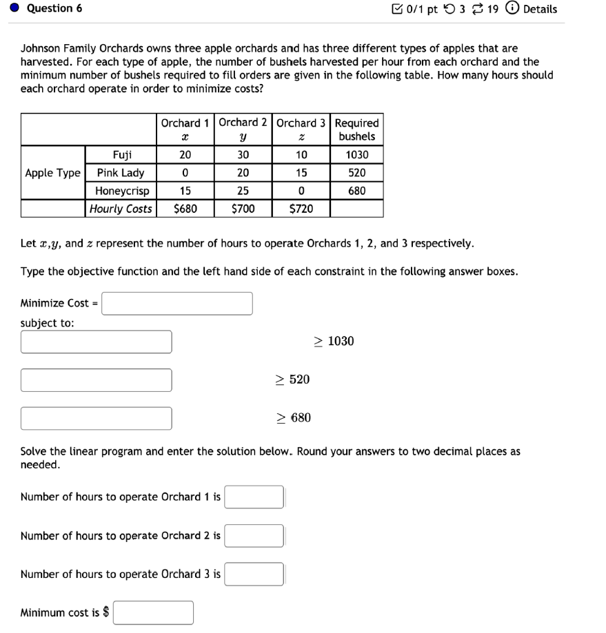

**Setup:**  
Minimize: $w=680y_1 + 700y_2 + 720y_3$  
Subject to:  
$20y_1 + 30y_2 + 10y_3 \geq 1030$  
$20y_2 + 15y_3 \geq 520$  
$15y_1 + 25y_2 \geq 680$  
$y_1 \geq 0, y_2 \geq 0, y_3 \geq 0$

```python
from pulp import LpVariable, LpProblem, LpMaximize, GLPK, LpStatus, value, LpMinimize

model = LpProblem("problem", LpMinimize)
y1 = LpVariable("y1", 0, None) # y1 >= 0
y2 = LpVariable("y2", 0, None) # y2 >= 0
y3 = LpVariable("y3", 0, None) # y3 >= 0

model += 20*y1 + 30*y2 + 10*y3 >= 1030
model += 20*y2 + 15*y3 >= 520
model += 15*y1 + 25*y2 >= 680

model += 680*y1 + 700*y2 + 720*y3

# solve the problem
status = model.solve()
LpStatus[status]

print("Number of hours to operate Orchard 1:",value(y1))
print("Number of hours to operate Orchard 2:",value(y2))
print("Number of hours to operate Orchard 3:",value(y3))

maximum_calories = 680 * value(y1) + 700 * value(y2) + 720 * value(y3)

print('\nMinimum Cost is $',round(maximum_calories,2))
```

```
Number of hours to operate Orchard 1: 0.0
Number of hours to operate Orchard 2: 34.333333
Number of hours to operate Orchard 3: 0.0

Minimum Cost is $ 24033.33
```

**Problem 6**  
Begin by simplifying the contraints:  
Minimize: $w=680y_1 + 700y_2 + 720y_3$  
Subject to:  
$2y_1 + 3y_2 + y_3 \geq 103$  
$4y_2 + 3y_3 \geq 104$  
$3y_1 + 5y_2 \geq 136$  
$y_1 \geq 0, y_2 \geq 0, y_3 \geq 0$  
The augmented matrix is: \begin{equation} \begin{bmatrix} \begin{array}{ccc|c} 2 & 3 & 1 & 103 \\ 0 & 4 & 3 & 104 \\ 3 & 5 & 0 & 136 \\ \hline 680 & 700 & 720 & 0 \\ \end{array} \end{bmatrix} \end{equation}  
Transpose the matrix:  
\begin{equation} \begin{bmatrix} \begin{array}{ccc|c} 2 & 0 & 3 & 680 \\ 3 & 4 & 5 & 700 \\ 1 & 3 & 0 & 720 \\ \hline 103 & 104 & 136 & 0 \\ \end{array} \end{bmatrix} \end{equation}  
The dual problem is:  
Maximize $z=103x_1+104x_2+136x_3$  
s.t:  
$2x_1+x_3\leq 680$  
$3x_1+4x_2+5x_3\leq 700$  
$x_1+3x_2\leq 720$  
$x_1\geq 0, x_2\geq 0, x_3\geq 0$  
Set up the initial tableau and use the Simplex method to solve:  
\begin{equation} \begin{bmatrix} \begin{array}{ccccccc|c} x_1 & x_2 & x_3 & s_1 & s_2 & s_3 & z & \enspace \\ 2 & 0 & 3 & 1 & 0 & 0 & 0 & 680 \\ 3 & 4 & 5 & 0 & 1 & 0 & 0 & 700 \\ 1 & 3 & 0 & 0 & 0 & 1 & 0 & 720 \\ \hline -103 & -104 & -136 & 0 & 0 & 0 & 1 & 0 \\ \end{array} \end{bmatrix} \end{equation}  
The pivot is the 5 in column 3:  
$-3R_2+5R_2\rightarrow R_1$  
$136R_2+5R_4\rightarrow R_4$  
\begin{equation} \begin{bmatrix} \begin{array}{ccccccc|c} x_1 & x_2 & x_3 & s_1 & s_2 & s_3 & z & \enspace \\ 1 & -12 & 0 & 5 & -3 & 0 & 0 & 1300 \\ 3 & 4 & 5 & 0 & 1 & 0 & 0 & 700 \\ 1 & 3 & 0 & 0 & 0 & 1 & 0 & 720 \\ \hline -107 & 24 & 0 & 0 & 136 & 0 & 5 & 95200 \\ \end{array} \end{bmatrix} \end{equation}  
The next pivot is the 3 in column 1:  
$-R_2+3R_1\rightarrow R_1$  
$-R_2+3R_3\rightarrow R_3$  
$107R_2+3R_4\rightarrow R_4$  
\begin{equation} \begin{bmatrix} \begin{array}{ccccccc|c} x_1 & x_2 & x_3 & s_1 & s_2 & s_3 & z & \enspace \\ 0 & -40 & -5 & 15 & -10 & 0 & 0 & -3200 \\ 3 & 4 & 5 & 0 & 1 & 0 & 0 & 700 \\ 0 & 5 & -5 & 0 & -1 & 3 & 0 & 1460 \\ \hline 0 & 500 & 535 & 0 & 515 & 0 & 15 & 360500 \\ \end{array} \end{bmatrix} \end{equation}  
Divide the bottom row by $15$ and read from the tableau:  
\begin{equation} \begin{bmatrix} \begin{array}{ccccccc|c} x_1 & x_2 & x_3 & s_1 & s_2 & s_3 & z & \enspace \\ 0 & -40 & -5 & 15 & -10 & 0 & 0 & -3200 \\ 3 & 4 & 5 & 0 & 1 & 0 & 0 & 700 \\ 0 & 5 & -5 & 0 & -1 & 3 & 0 & 1460 \\ \hline 0 & 33.33 & 35.67 & 0 & 34.33 & 0 & 1 & 24033.33 \\ \end{array} \end{bmatrix} \end{equation}  
$y_1=0, y_2=34.33, y_3=0, w=24033.33$

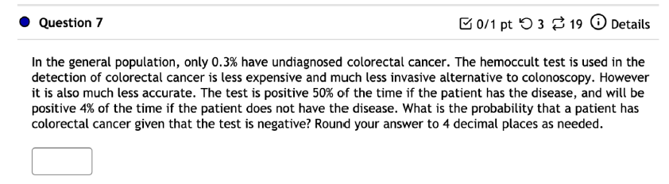

```python
P_cancer = 0.003

P_positive_cancer = 0.5
P_negative_cancer = 1 - P_positive_cancer
P_positive_no_cancer = 0.04
P_negative_no_cancer = 1 - P_positive_no_cancer

# Using law of total probability

P_negative = P_negative_cancer * P_cancer + P_negative_no_cancer*(1-P_cancer)

# Using bayes theorem

P_cancer_negative = 0.5*0.003/P_negative

print(round(P_cancer_negative,4))
```

```
0.0016
```

**Problem 7**  
Let:  
$C=$ patient has undiagnosed colorectal cancer  
$N=$ patient tests negative  
We need to find $P(C|N)$ using Bayes' Theorem.  
\begin{equation} P(C|N)=\frac{P(C)\cdot P(N|C)}{P(C)\cdot P(N|C)+P(C')\cdot P(N|C')} \end{equation}  
$P(C)=0.003$  
$P(C')=0.997$  
$P(N|C)=0.5$  
$P(N|C')=0.96$  
\begin{equation} P(C|N)=\frac{(0.003)(0.5)}{(0.003)(0.5)+(0.997)(0.96)}\approx 0.0016 \end{equation}

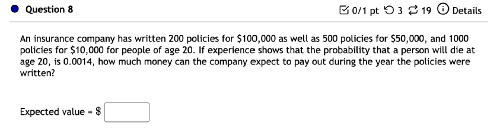

```python
# Lets refer to these as three batches
first = 200
second = 500
third = 1000

# Amounts the policies were written out for
first_amount = 100000
second_amount = 50000
third_amount = 10000

# Probability that person will die at age 20
prob = 0.0014

# payouts
first_payout = first*first_amount*prob
second_payout = second*second_amount*prob
third_payout = third*third_amount*prob

# Total payout
total_payout = first_payout + second_payout + third_payout
print("Expected value = $",total_payout)
```

```
Expected value = $ 77000.0
```

**Problem 8**  
$E(x)=(0.0014)[200(100000)+500(50000)+1000(10000)]=77000$

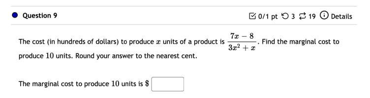

```python
import sympy

x = sympy.Symbol('x')

cost = (7*x-8)/(3*x**2 + x)

marginal_cost = cost.diff(x)

print("Marginal cost to produce 10 units is $",round(marginal_cost.subs(x,10)*100,2))
```

```
Marginal cost to produce 10 units is $ -1.68
```

**Problem 9**  
\begin{equation} C'(x)=\frac{7(3x^2+x)-(6x+1)(7x-8)}{(3x^2+x)^2} \end{equation}  
\begin{equation} =\frac{21x^2+7x-(42x^2-41x-8)}{(3x^2+x)^2} \end{equation}  
\begin{equation} =\frac{-21x^2+48x+8}{(3x^2+x)^2} \end{equation}  
\begin{equation} C'(10)=\frac{-21(100)+48(10)+8}{[3(100)+10]^2} \end{equation}  
\begin{equation} =\frac{-1612}{96100}\approx -0.0168 \end{equation}  
Convert to hundreds of dollars: The marginal cost to produce $10$ units is $-\$1.68$

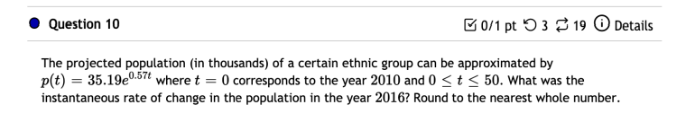

```python
import sympy

t = sympy.Symbol('t')

f = 35.19 * sympy.exp(0.57*t)

df = f.diff(t)

print(int(df.subs(t,6)*1000), "people per year")
```

```
613170 people per year
```

**Problem 10**  
$p'(t)=(0.57)(35.19^{0.57t})=20.0583e^{0.57t}$  
Since $t=0$ corresponds to $2010$, $t=6$ corresponds to $2016$.  
$p'(6)=20.0583e^{(0.57)(6)}\approx 613.170497$  
Convert to thousands: The rate of change in the population in $2016$ was $613170$ people per year.  
**Caution: *Never round until the very last step*.**

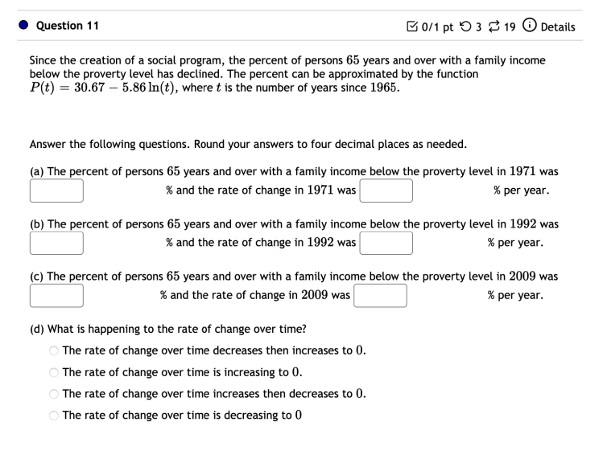

```python
import sympy

t = sympy.Symbol('t')

f = 30.67 - 5.86 * sympy.ln(t)
f_diff = f.diff(t)

f_l = sympy.lambdify(t, f)
f_diff_l = sympy.lambdify(t, f_diff)

base = 1965
years = [1971, 1992, 2009]

for year in years:
    pct = f_l(year-base)
    rate = f_diff_l(year-base)
    print(f"In {year} the percent of persons over 65 in poverty was {pct:.4f} and the rate of change was {rate:.4f}")
```

```
In 1971 the percent of persons over 65 in poverty was 20.1703 and the rate of change was -0.9767
In 1992 the percent of persons over 65 in poverty was 11.3564 and the rate of change was -0.2170
In 2009 the percent of persons over 65 in poverty was 8.4946 and the rate of change was -0.1332
```

**Problem 11**  
First find $P'(t)$:  
$P'(t)=-5.86/t$  
(a)  
$1971$ corresponds to $t=6$:  
$P(6)=30.67-5.86\ln (6)\approx 20.1703$  
$P'(6)=-5.86/6\approx -0.9767$  
The percent of persons $65$ and over with a family income below the poverty level in 1971 was $20.1703\%$ and the rate of change was $-0.9767\%$ per year.  
(b)  
$1992$ corresponds to $t=27$  
$P(27)=30.67-5.86\ln (27)\approx 11.3564$  
$P'(27)=-5.86/27\approx -0.2170$  
The percent of persons $65$ and over with a family income below the poverty level in 1992 was $11.3564\%$ and the rate of change was $-0.2170\%$ per year.  
(c)  
$2009$ corresponds to $t=44$  
$P(44)=30.67-5.86\ln (44)\approx 8.4946$  
$P'(44)=-5.86/44\approx -0.1332$  
The percent of persons $65$ and over with a family income below the poverty level in 2009 was $8.4946\%$ and the rate of change was $-0.1332\%$ per year.  
(d)  
To determine the rate of change over time, calculate the limit of $P'(t)$ as $t\rightarrow\infty$:  
\begin{equation} \lim_{t\rightarrow\infty}(-5.86/t)=0 \end{equation}  
Because the derivative is always negative, $P'(t)$ is approaching $0$ from the left (negative) side of $0$. Thus, the rate of change over time is increasing to $0$.

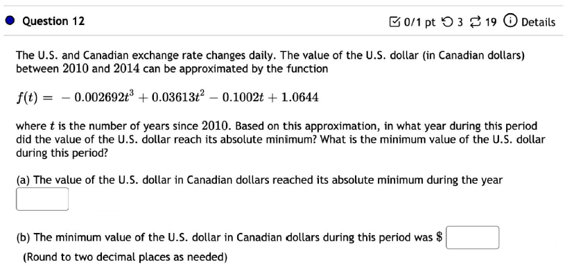

```python
import sympy
t = sympy.Symbol('t')
f = -0.002692*t**3 + 0.03613*t**2 - 0.1002*t + 1.0644

f_t = sympy.lambdify(t, k)
f_diff = f.diff(t)

roots = sympy.solveset(sympy.Eq(f_diff, 0), t)
print(f"The extrema for this equation are {roots}")

for root in roots:
    val_at_root = f_t(root)
    print(f"After {root} years the value is {val_at_root}")

# The value of the U.S. dollar in Canadian dollars is reached its minimum during 2011 [2010 + 1.7]
# The minimum value of the U.S. dollar in Canadian dollars during this period was $ 0.98
```

[output not shown]

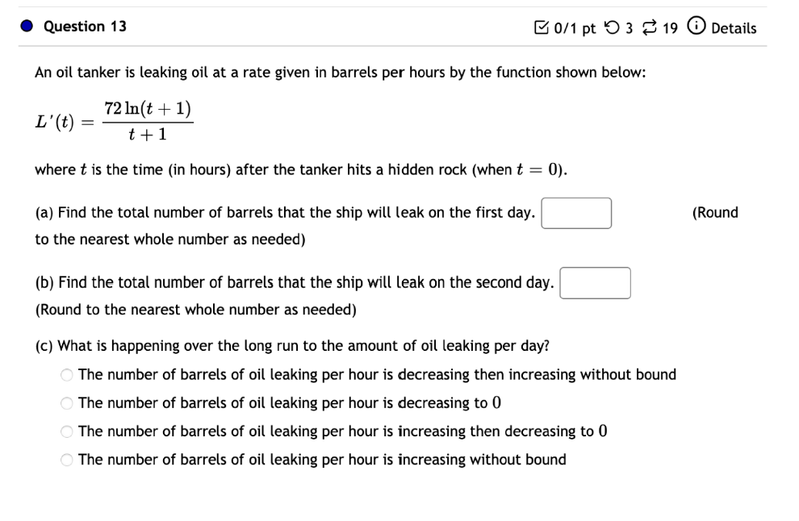

```python
import sympy
t = sympy.Symbol('t')
function = 72*sympy.ln(t+1)/(t+1)

num_barrels_day_1 = int(sympy.integrate(function, (t,0,24)))

print ("The total number of barrels that the ship will leak on the first day =",num_barrels_day_1)

num_barrels_day_2 = int(sympy.integrate(function, (t,24,48)))

print ("The total number of barrels that the ship will leak on the second day =",num_barrels_day_2)
```

```
The total number of barrels that the ship will leak on the first day = 373
The total number of barrels that the ship will leak on the second day = 172
```

**Problem 13**  
Since we're given the rate of change, we need to integrate to find total change. First find the indefinite integral using substitution:  
Let $u=\ln (t+1).$ Then $du=1/(t+1)dt$. So:  
\begin{equation} \int\frac{72\ln (t+1)}{t+1}dt=72\int udu \end{equation}  
\begin{equation} =\frac{72u^2}{2}+C=36u^2+C=36(\ln (t+1))^2+C \end{equation}  
(a) Notice $t$ is given in hours, so we need to convert days to hours and integrate from $0$ to $24$.  
$36[(\ln (25))^2-(\ln (1))^2]\approx 373$  
(b) The limits of integration are from $24$ to $48$:  
$36[(\ln (49))^2-(\ln (25))^2]\approx 172$  
(c) The number of barrels of oil leaking per hour is decreasing to $0$.

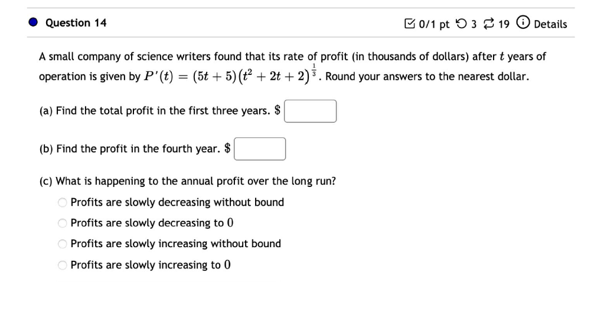

```python
import sympy
t = Symbol('t')
profit = (5*t+5)*((t**2+2*t+2)**(1/3))

profit_first_3_yrs = (sympy.integrate(profit, (t,0,3))*1000)

print ("Total profit in first three years = ${.1f}",round(profit_first_3_yrs,0))

profit_4th_yr = (sympy.integrate(profit, (t,3,4))*1000)

print ('Profit in fourth years = $',round(profit_4th_yr,0))
```

```
Total profit in first three years = ${.1f} 77235.0000000000
Profit in fourth years = $ 62462.0000000000
```

**Problem 14**  
Solve using substitution and first find the indefinite integral.  
Let $u=t^2+2t+2$ so $du=2(t+1)dt$ and $1/2du=(t+1)dt$:  
\begin{equation} \frac{5}{2}\int u^{1/3}du=\frac{5}{2}\left(\frac{u^{4/3}}{4/3}\right)+C=\frac{15u^{4/3}}{8}+C \end{equation}  
\begin{equation} =\frac{15(t^2+2t+2)^{4/3}}{8}+C \end{equation} (a)Evaluate the integral from $0$ to $3$:  
\begin{equation} =\frac{15(9+6+2)^{4/3}}{8}-\frac{15(0+0+2)^{4/3}}{8}\approx 77.235 \end{equation}  
The total profit in the first three years was $\$77235$  
(b) Evaluate the integral from $3$ to $4$:  
\begin{equation} =\frac{15(16+8+2)^{4/3}}{8}-\frac{15(9+6+2)^{4/3}}{8}\approx 62.462 \end{equation}  
The total profit in the fourth year was $\$62462$  
(c) The calculations for (a) and (b) are for total change in the first three years and total change in the fourth year, respectively. Evaluate the integral from $0$ to $1$, $1$ to $2$, and $2$ to $3$ to see the pattern. The annual profits are increasing without bound over time.

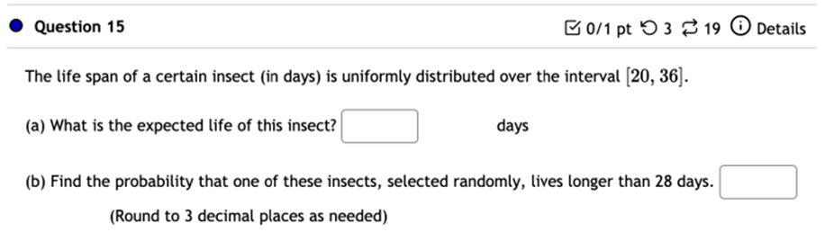

```python
low_end = 20
high_end = 36
life_range = high_end - low_end

a = life_range / 2 + low_end

print(f"(a) {a}")

b = (life_range - 8) / life_range

print(f"(b) {b}")
```

```
(a) 28.0
(b) 0.5
```

**Problem 15**  
The probability density function for the uniform distribution is given by:  
\begin{equation} f(x)=\frac{1}{36-20}=\frac{1}{16} \end{equation}  
(a) The expected value is $(1/2)(20+36)=28$ days  
(b) Since the uniform distribution is symmetric about the mean and the mean is 28, the probability that a randomly selected insect lives longer than $28$ days is $0.5$.

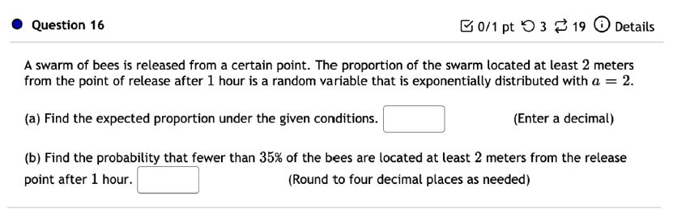

```python
import sympy

x = sympy.Symbol('x')
l = 2

expected_value = 1 / l  # Expected value formula for exponential distribution
print(f"The expected proportion of an exponential distribution, in this case the bee dispersal, is {expected_value}")

cdf_exp = 1 - sympy.exp(-l * x)  # CDF for exponential distribution
cdf_exp_func = sympy.lambdify(x, cdf_exp)
print(f"The probability that fewer than 35% are located within 2 meters is {cdf_exp_func(.35):.04}")
```

```
The expected proportion of an exponential distribution, in this case the bee dispersal, is 0.5
The probability that fewer than 35% are located within 2 meters is 0.5034
```

**Problem 16**  
The exponential distribution is given by $f(x)=ae^{-ax}=2e^{-2x}$, where $\mu =1/a=1/2$ and $\sigma = 1/a=1/2$.  
(a) The expected proportion is the mean, which is $1/2$.  
(b) The probability is determined by integrating the exponential distribution from $0$ to $0.35$:  
\begin{equation} \int_{0}^{0.35}-2e^{-2x}dx=-e^{-2x}\Big|_{0}^{0.35}=-e^{-0.7}+1\approx 0.5034 \end{equation}

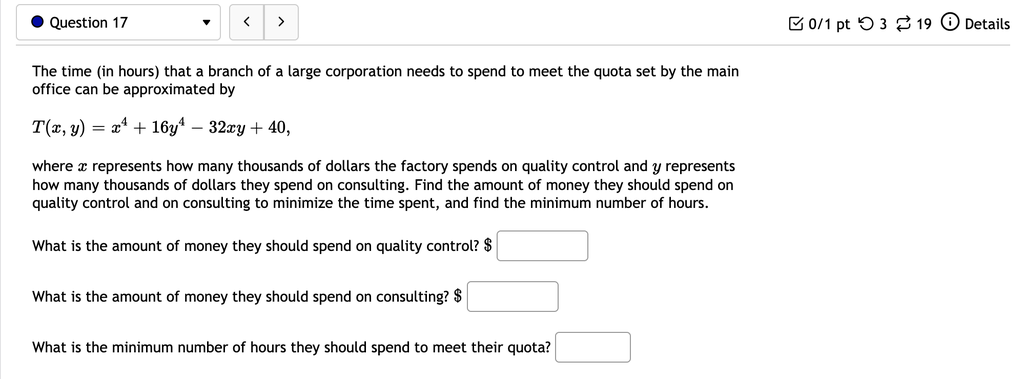

**Problem 17**  
Begin by finding the first partials and set each equal to $0$ to solve for relative extrema:  
$T_x(x,y)=4x^3-32y$ and $T_y(x,y)=64y^3-32x$  
$4x^3-32y=0\rightarrow y=x^3/8$  
$64y^3-32x=0\rightarrow x=2y^3$  
Substitute $x=2y^3$ into $y=x^3/8$ and solve for $y$:  
$y=(2y^3)^3/8\rightarrow y=y^9$  
$y(y^8-1)=0\rightarrow y=0, 1$  
If $y=0$, then $x=0$ and if $y=1$, then $x=2$.  
Next find $T_{xx}(x,y), T_{yy}(x,y)$, and $T_{xy}(x,y)$:  
$T_{xx}(x,y)=12x^2$, $T_{yy}(x,y)=192y^2$, $T_{xy}(x,y)=-32$  
$T_{xx}(0,0)=0$, $T_{yy}(0,0)=0$, $T_{xy}(x,y)=-32\rightarrow D=0*0-(-32)^2<0$, so there is a saddle point at $(0,0)$.  
$T_{xx}(2,1)=48$, $T_{yy}(2,1)=192$, $T_{xy}(2,1)=-32\rightarrow D=48*92-(-32)^2>0$.  
$T_xx(2,1)>0$, so $(2,1)$ is a relative minimum.  
Since $x$ represents thousands of dollars, the corporation should spend $\$2000$ on quality control and $\$1000$ on consulting. $T(2,1)=16+16-64+40=8$, so they should spend a minimum of $8$ hours to meet their quota.

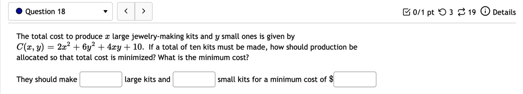

**Problem 18**  
The constraint in this problem is $x+y=10$, so rewite this as $g(x,y)=0$:  
$g(x,y)=x+y-10=0$  
Next, form the Lagrange function $F(x,y,\lambda)=C(x,y)-\lambda\cdot g(x,y)$  
$F(x,y,\lambda)=2x^2+6y^2+4xy+10-\lambda(x+y-10)$  
$=2x^2+6y^2+4xy+10-\lambda x-\lambda y +10\lambda$  
Next find $F_x(x,y,\lambda)$, $F_y(x,y,\lambda)$, and $F_\lambda(x,y,\lambda)$:  
$F_x(x,y,\lambda)=4x+4y-\lambda$  
$F_y(x,y,\lambda)=12y+4x-\lambda$  
$F_\lambda(x,y,\lambda)=-x-y+10$  
Set each partial derivative equal to $0$ and form a system of equations:  
$4x+4y-\lambda =0$  
$4x+12y-\lambda =0$  
$-x-y+10=0$  
Now solve the system:  
$4x+4y-\lambda=0\rightarrow \lambda=4x+4y$  
$4x+12y-\lambda=0\rightarrow\lambda=4x+12y$, so  
$4x+4y=4x+12y\rightarrow y=0$  
If $y=0$, then $x=10$. So they should make $10$ large kits and $0$ small kits for a minimum cost of $\$210$.

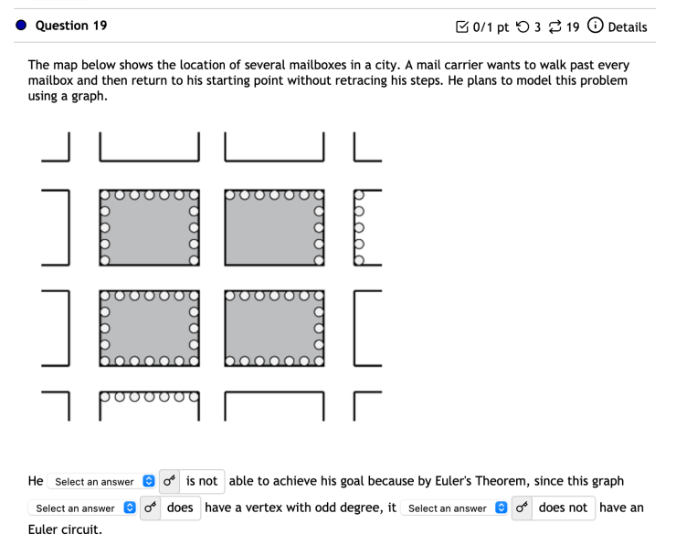

```python
block1_verticies = 15
block2_verticies = 11
block3_verticies = 5
block4_verticies = 20
block5_verticies = 17
block6_verticies = 7

total_verticies = sum([
    block1_verticies,
    block2_verticies,
    block3_verticies,
    block4_verticies,
    block5_verticies,
    block6_verticies
])

is_odd = 1 == total_verticies % 2  # is true if a number divided by 2 has a remainder of 1

print(f"The number of verticies is odd: {is_odd}")
```

```
The number of verticies is odd: True
```

He [is not] able to achieve his goal because by Euler's Theorem, since this graph [does] have a vertex with odd degree, it [does not] have a Euler circuit.

**Problem 19**  
The written approach to this problem is much different than the solution in Python. The first thing to do it to sketch the graph of this scenario. We can think of the vertices as the street corners and each side of the road as an edge. So there are $9$ vertices and $14$ edges. Next, consider the image with vertices labeled:

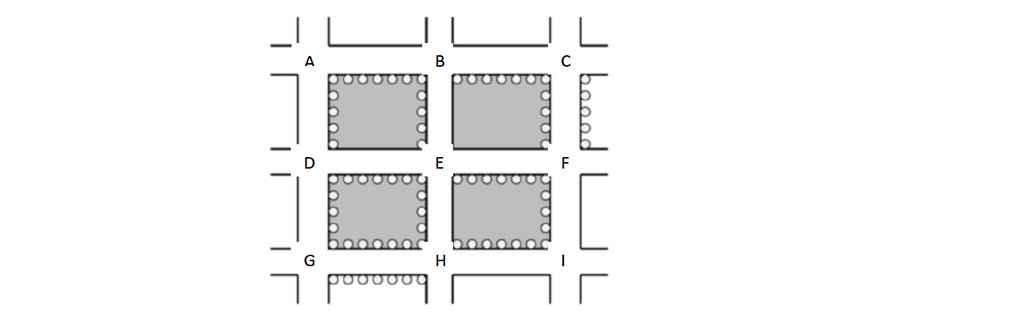

Now consider the degrees of each vertex. In order from $A$ through $I$, the degrees are $2, 3, 3, 3, 4, 4, 3, 4, 2$. Since there is at least one vertex with odd degree, there is not an Euler circuit.

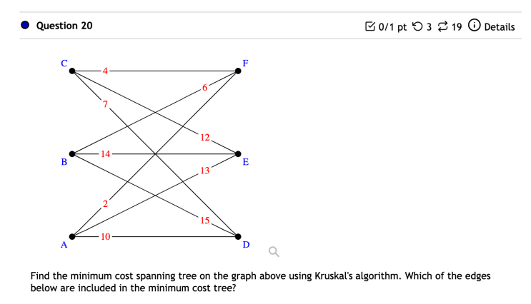

```python
# This is a copy/paste of the Node and Graph class from the Graph Theory Notebook.
# The kruskal method on the Graph class is the only thing added here.
import string

class Node(object):
    '''
    This is a class that represents a node. The functions of a class are called methods. Instantiations of this class
    will create objects that have access to the methods.

    Each method begins with an argument of "self" which lets the methos know which object it belongs to.

    For the Node object, we care about the name of the node and a dictionary naming the adjacent nodes. The adjacent
    dictionary keys will be the name's of adjacent nodes and the value will be the weight of that edge.
    '''
    def __init__(self, name):
        # The init method is magic python method that get's called when an object is instantiated.
        self.name = name  # Take the name given at instantiation and assign it to the object
        self.adjacent = {}  # When we create the node, we don't know about any adjacent nodes. Create a placeholder

    def __str__(self):
        # When printing a node, format it like this:
        return "Node {}: {}".format(self.name, self.adjacent)

    def __repr__(self):
        # When representing this object, use the str method
        return self.__str__()

class Graph(object):
    '''
    This class represents a graph. The graph is consists of a collection of nodes.
    '''
    def __init__(self, adjacency_matrix=None):
        '''
        When the graph is instantiated it will not know about any of its member nodes. There is an optional
        `adjacency_matrix` argument that defaults to None. If an adjacency_matrix is provided, then we can
        create the member nodes, their relationships, and add them to this graph.
        '''
        self.nodes = {}
        if adjacency_matrix:
            # We were provided an adjacency matrix
            self._create_member_nodes_from_adjacency_matrix(adjacency_matrix)

    def __str__(self):
        return '\n'.join([str(n) for n in self.nodes.values()])

    def __repr__(self):
        return self.__str__()

    def _create_member_nodes_from_adjacency_matrix(self, adjacency_matrix):
        # A preceeding underscore indicates a method that is only called within the class.
        # Create nodes and weights from an adjacency matrix (list of lists) and assign them to this graph
        letters = list(string.ascii_lowercase)  # Get a list of letters to assign to the nodes we create
        needed_letters = len(adjacency_matrix)
        if needed_letters > len(letters):
            # Give the user an error that the input matrix is too large to have
            raise ValueError("The matrix is too large to create from 26 letters. Please manually assign names to nodes and then add them to the graph.")

        for i, row in enumerate(adjacency_matrix):  # get an index of the row and the contentx of the row
            letter_name = letters[i]
            node = Node(letter_name)
            for j, column_value in enumerate(row):
                if column_value != 0:  # There is an adjacent node here
                    adjacent_letter_name = letters[j]
                    node.adjacent[adjacent_letter_name] = column_value
            self.nodes[letter_name] = node

    def get_distance_of_path(self, path):
        # Given a list of node names within the graph, find its distance using the node adjacency measures
        distance = 0
        for i, node_name in enumerate(path[:-1]):
            # Gets the index and node name for each in the path except for the last one
            this_node = self.nodes[node_name]
            next_node = self.nodes[path[i+1]]
            distance += this_node.adjacent[next_node.name]  # Get the distance from this_node to next node

        return distance

    def find_all_paths_between(self, a, b, path=None):
        if not path:
            # No path list provided, create one
            path = []

        path = path + [a] # Add a to the path

        if a == b:  # This is a path to itself, at the end of a path
            return [path]
        if a not in self.nodes:  # a could not be found in the graph
            return []
        paths = []
        for node in self.nodes[a].adjacent:  # look to adjacent nodes of a
            if node not in path:
                newpaths = self.find_all_paths_between(node, b, path)  # Recursivly go down another level
                for newpath in newpaths:
                    paths.append(newpath)
        return paths

    def shortest_path(self, a, b):
        # Get the distance of each weighted path and return the shortest
        all_paths = self.find_all_paths_between(a, b)

        if not all_paths:
            return []

        # The shortest path will be the first path in the list
        shortest_path = None
        shortest_distance = None

        for path in all_paths:
            p_distance = self.get_distance_of_path(path)
            if not shortest_distance or p_distance < shortest_distance:
                # This path is shorter
                shortest_path = path
                shortest_distance = p_distance

        return shortest_path

    def is_tree(self):
        # returns True if the graph is a tree, otherwise False

        node_names = list(self.nodes.keys())
        first = node_names[0]  # Make sure the first node has a path to all other nodes

        for node in node_names:
            if node == first:
                continue  # Don't compare it against itself
            if not self.find_all_paths_between(first, node):
                return False  # No path was found between first and node, this must not be a tree

        return True


    def kruskal(self):
        # Find the minimum cost spanning tree on the graph using Kruskal's algorithm

        # Loop through the graph to get a deduplicated list of edges
        unique_edge_lenghts = dict()
        for node, connections in self.nodes.items():
            for connected, edge_length in connections.adjacent.items():
                alpha_edge = sorted([node, connected])

                edge_name = "-".join(alpha_edge)  # keeps nodes alphabetical to dedupe
                unique_edge_lenghts[edge_name] = edge_length

        # This sorts the edges by their lengths desc
        sorted_unique_edge_lengths = dict(sorted(unique_edge_lenghts.items(), key=lambda x:x[1]))

        # proceed through the sorted list and add the edge if it contains a new node.
        selected_nodes = set()
        selected_edges = list()
        for edge in sorted_unique_edge_lengths.keys():
            a, b = edge.split('-')
            if a in selected_nodes and b in selected_nodes:
                continue  # No circuits here
            selected_nodes.add(a)
            selected_nodes.add(b)
            selected_edges.append(edge)

        return selected_edges
```

```python
matrix = [
    #A   B   C  D   E   F
    [0,  0,  0, 10, 13, 2],  # A
    [0,  0,  0, 15, 14, 6],  # B
    [0,  0,  0,  7, 12, 4],  # C
    [10, 15, 7,  0, 0,  0],  # D
    [13, 14, 12, 0, 0,  0],  # E
    [2,  6,  4,  0, 0,  0]   # F
]

g = Graph(matrix)

print(f"The selected graph edges for the minimum tree is {g.kruskal()}")
```

```
The selected graph edges for the minimum tree is ['a-f', 'c-f', 'b-f', 'c-d', 'c-e']
```

**Problem 20**  
Apply Kruskal's algorithm and order the edges by weight in ascending order:  
$AF\rightarrow 2$  
$CF\rightarrow 4$  
$BF\rightarrow 6$  
$CD\rightarrow 7$  
$AD\rightarrow 10$  
$CE\rightarrow 12$  
$AE\rightarrow 13$  
$BE\rightarrow 14$  
$BD\rightarrow 15$  
Add edges in order except if adding an edge forms a circuit. Once all vertices have been used, the spanning tree is complete.  
$AF\rightarrow CF\rightarrow BF\rightarrow CD\rightarrow$ **$AD$ forms a circuit**  
$AF\rightarrow CF\rightarrow BF\rightarrow CD\rightarrow CE$ and the spanning tree is complete.  
The total weight of the edges is $2+4+6+7+12=31$.